# Craigslist

## Scraping Craigslist

In this part, I'll be extracting information on apartments from Craigslist search results. I'll be using BeautifulSoup to extract the relevant information from the HTML text.

For reference on CSS selectors, please see the [notes from Week 6](https://github.com/MUSA-620-Spring-2019/week-6/blob/master/css-selectors.md).

### Getting the HTML

First we need to figure out how to submit a query to Craigslist. As with many websites, one way you can do this is simply by constructing the proper URL and sending it to Craigslist. Here's a sample URL that is returned after manually typing in a search to Craigslist:

http://philadelphia.craigslist.org/search/apa?bedrooms=1&pets_cat=1&pets_dog=1&is_furnished=1

There are two components to this URL:

1. The base URL: `http://philadelphia.craigslist.org/search/apa`
2. The user's search parameters: `?bedrooms=1&pets_cat=1&pets_dog=1&is_furnished=1`

We will use `requests.get()` function to get the search page's response. For the search parameters, we will set `bedrooms=1`, which will make sure the number of bedrooms is listed.

This can be done easiest by using the `params` keyword of the `get()` function. We didn't cover this in the lecture, so I've went ahead and done the necessary steps.

```python
import requests
```

```python
url_base = 'http://philadelphia.craigslist.org/search/apa'
params = {'bedrooms': 1}
rsp = requests.get(url_base, params=params)
```

```python
# Note that requests automatically created the right URL
print(rsp.url)
```

```
https://philadelphia.craigslist.org/search/apa?bedrooms=1
```

## 1.1 Parse the HTML

- Use BeautifulSoup to parse the HTML response.
- Use the browser's Web Inspector to identify the HTML element that holds the information on each apartment listing.
- Use BeautifulSoup to extract these elements from the HTML.

There should have a list of 120 elements, where each element is the listing for a specific apartment on the search page.

```python
from bs4 import BeautifulSoup
```

```python
soup = BeautifulSoup(rsp.content, 'html.parser')
```

```python
selector = "#sortable-results > ul li"
rows = soup.select(selector)
```

```python
len(rows)
```

```
120
```

## 1.2 Find the relevant pieces of information

We will now focus on the first element in the list of 120 apartments. Use the `prettify()` function to print out the HTML for this first element.

From this HTML, identify the HTML elements that hold:

- The apartment price
- The number of bedrooms and square footage (this will be in a single element)
- The apartment title
- The datetime string of the posting, e.g., '2019-03-23 12:07'

For the first apartment, print out each of these pieces of information, using BeautifulSoup to select the proper elements.

**Hint:** Each of these can be extracted using the `text` attribute of the selected element object, except for the datetime string. This information is stored as an *attribute* of an HTML element and is not part of the displayed text on the webpage.

```python
row1 = rows[0]
print(row1)
```

```
<li class="result-row" data-pid="6996641837">
<a class="result-image gallery" data-ids="1:01313_1t9aTqORgdQ,1:00k0k_bRDYZpe7dGU,1:00Y0Y_7cbgohNddMs,1:00e0e_798ZPzjNWfs,1:00Q0Q_b3mzZNQofaQ,1:00c0c_56du9BbE4Ea,1:00t0t_2TnzjnrmfSi,1:01010_iRpcSPphm8O,1:00F0F_3OWjQiYqlyf,1:00P0P_llMScLd8LiN,1:00r0r_4nFnjwWbvg1" href="https://philadelphia.craigslist…
<span class="result-price">$1805</span>
</a>
<p class="result-info">
<span class="icon icon-star" role="button">
<span class="screen-reader-text">favorite this post</span>
</span>
<time class="result-date" datetime="2019-10-29 18:58" title="Tue 29 Oct 06:58:45 PM">Oct 29</time>
<a class="result-title hdrlnk" data-id="6996641837" href="https://philadelphia.craigslist.org/apa/d/west-chester-pet-friendly-two-dog-parks/6996641837.html">Pet Friendly, Two Dog Parks, Nature Trails,  BBQ Stations &amp; MORE!</a>
<span class="result-meta">
<span class="result-price">$1805</span>
<span class="housing">
                    2br -
                </span>
<span class="result-hood"> (Pet Friendly! 2 Dog Parks!)</span>
<span class="result-tags">
<span class="pictag">pic</span>
</span>
<span class="banish icon icon-trash" role="button">
<span class="screen-reader-text">hide this posting</span>
</span>
<span aria-hidden="true" class="unbanish icon icon-trash red" role="button"></span>
<a class="restore-link" href="#">
<span class="restore-narrow-text">restore</span>
<span class="restore-wide-text">restore this posting</span>
</a>
</span>
</p>
</li>
```

```python
price = row1.select_one('span.result-price').text
print(price)
```

```
$1805
```

```python
nbed_area = row1.select_one('span.housing').text
print(nbed_area)
```

```
                    2br -
```

```python
title = row1.select_one('p > a').text
print(title)
```

```
Pet Friendly, Two Dog Parks, Nature Trails,  BBQ Stations & MORE!
```

```python
datetime = row1.select_one('p > time')['datetime']
print(datetime)
```

```
2019-10-29 18:58
```

## 1.3 Functions to format the results

In this section, I'll create two functions that take the price and time results from the last section and format them properly.

```python
import re
```

```python
def format_size_and_bedrooms(size_string):
    """
    Extract size and number of bedrooms from the raw
    text, using regular expressions
    """
    split = re.findall("\n(.*?) -", size_string)

    # both size and bedrooms are listed
    if len(split) == 2:
        n_brs = split[0].strip().replace('br', '')
        this_size = split[1].strip().replace('ft2', '')
    # only bedrooms is listed
    elif 'br' in split[0]:
        n_brs = split[0].strip().replace('br', '')
        this_size = np.nan
    # only size is listed
    elif 'ft2' in split[0]:
        # It's the size
        this_size = split[0].strip().replace('ft2', '')
        n_brs = np.nan

    # return floats
    return float(this_size), float(n_brs)
```

```python
def format_price(price_string):
    # Format the price string and return a float
    # This will involve using the string.strip() function to remove unwanted characters
    this_price = price_string.strip('$')
    return float(this_price)
```

```python
from datetime import datetime
```

```python
def format_time(date_string):
    # Return a Datetime object from the datetime string
    datetime_object = pd.to_datetime(date_string, format = '%Y-%m-%d %H:%M')
    #datetime_object = datetime_object.to_pydatetime()
    return datetime_object
```

```python
print(format_time(datetime))
```

```
2019-10-29 18:58:00
```

## 1.4: Putting it all together

In the code below, the outer for loop will loop over 5 pages of search results. The inner for loop will loop over the 120 apartments listed on each search page.

#### Notes

Be careful if you try to scrape more listings. Craigslist will temporarily ban your IP address (for a very short time) if you scrape too much at once. I've added a `sleep()` function to the for loop to wait 30 seconds between scraping requests.

If the for loop gets stuck at the "Processing page X..." step for more than a minute or so, your IP address is probably banned temporarily, and you'll have to wait a few minutes before trying again.

```python
from time import sleep
import numpy as np
import pandas as pd
```

```python
results = []

# search in batches of 120 for 5 pages
# NOTE: you will get temporarily banned if running more than ~5 pages or so
# the API limits are more leninient during off-peak times, and you can try
# experimenting with more pages
max_pages = 5
results_per_page = 120
search_indices = np.arange(0, max_pages*results_per_page, results_per_page)
url = 'http://philadelphia.craigslist.org/search/apa'

# loop over each page of search results
for i, s in enumerate(search_indices):
    print('Processing page %s...' % (i+1) )

    # get the response
    resp = requests.get(url, params={'bedrooms': 1, 's': s})

    # get the list of all aparements
    # It should be a list of 120 apartments
    apts = soup.select("#sortable-results > ul li")
    print("number of apartments = ", len(apts))

    # loop over each apartment in the list
    page_results = []
    for apt in apts:

        sizes_brs = apt.select_one('span.housing').text # the bedrooms/size string
        title = apt.select_one('p > a').text # the title string
        price = apt.select_one('span.result-price').text # the price string
        dtime = apt.select_one('p > time')['datetime'] # the time string

        # format using functions from Part 1.3
        sizes, brs = format_size_and_bedrooms(sizes_brs)
        price = format_price(price)
        dtime = format_time(dtime)

        # save the result
        page_results.append([dtime, price, sizes, brs, title])

    # create a dataframe and save
    col_names = ['time', 'price', 'size', 'brs', 'title']
    df = pd.DataFrame(page_results, columns=col_names)
    results.append(df)

    print("sleeping for 30 seconds between calls")
    sleep(30)

# Finally, concatenate all the results
results = pd.concat(results, axis=0)
```

```
Processing page 1...
number of apartments =  120
sleeping for 30 seconds between calls
Processing page 2...
number of apartments =  120
sleeping for 30 seconds between calls
Processing page 3...
number of apartments =  120
sleeping for 30 seconds between calls
Processing page 4...
number of apartments =  120
sleeping for 30 seconds between calls
Processing page 5...
number of apartments =  120
sleeping for 30 seconds between calls
```

```python
results
```

|  | time | price | size | brs | title |
| --- | --- | --- | --- | --- | --- |
| 0 | 2019-10-29 18:58:00 | 1805.0 | NaN | 2.0 | Pet Friendly, Two Dog Parks, Nature Trails, B... |
| 1 | 2019-10-29 18:55:00 | 3348.0 | 1462.0 | 2.0 | Fantastic Location, Beautiful Amenities, Luxur... |
| 2 | 2019-10-29 18:54:00 | 1479.0 | 651.0 | 1.0 | Come Home to Casa Del Sol |
| 3 | 2019-10-29 18:52:00 | 1100.0 | 1000.0 | 2.0 | 2 bedrooms apt for rent at 5015 Cedar |
| 4 | 2019-10-29 18:50:00 | 980.0 | 1100.0 | 4.0 | Housing Available for immediate rent |
| ... | ... | ... | ... | ... | ... |
| 115 | 2019-10-29 17:17:00 | 1395.0 | 1000.0 | 1.0 | ### Blue Bell - One Bedroom Brand new Bathroom... |
| 116 | 2019-10-29 17:17:00 | 1387.0 | 725.0 | 1.0 | Special Pricing On Select 1 Bed 1 Bath For Imm... |
| 117 | 2019-10-29 17:16:00 | 1305.0 | NaN | 1.0 | Two Pet Parks, Open Concept, BONUS ROOM! |
| 118 | 2019-10-29 17:16:00 | 1328.0 | 725.0 | 1.0 | Fall In Love With Your New Home Special Pricin... |
| 119 | 2019-10-29 17:15:00 | 1765.0 | 1184.0 | 2.0 | 2 Bedroom 2 full bath with fireplace! |

600 rows × 5 columns

## 1.5: Plotting the distribution of prices

Use matplotlib's `hist()` function to make two histograms for:

- Apartment prices
- Apartment prices per square foot (price / size)

Make sure to add labels to the respective axes and a title describing the plot.

### Side note: rental prices per sq. ft. from Craigslist

The histogram of price per sq ft should be centered around ~1.5. Here is a plot of how Philadelphia's rents compare to the other most populous cities:

[figure not shown]

[Source](https://arxiv.org/pdf/1605.05397.pdf)

```python
from matplotlib import pyplot as plt
%matplotlib inline
```

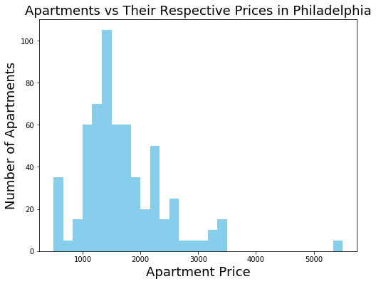

```python
fig, ax = plt.subplots(figsize=(8,6))

# Plot histogram
ax.hist(results['price'], bins=30, color = "skyblue")

ax.set_xlabel("Apartment Price", fontsize=18)
ax.set_ylabel("Number of Apartments", fontsize=18);
ax.set_title("Apartments vs Their Respective Prices in Philadelphia", fontsize=18);
```

The apartment prices in Philly have a distribution a bit skewed to the right, with mode at around $1500.

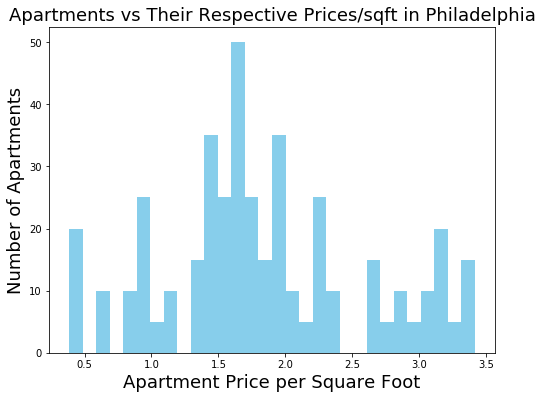

```python
fig, ax = plt.subplots(figsize=(8,6))

# Plot histogram
pricesqft = results['price']/results['size']
ax.hist(pricesqft[~np.isnan(pricesqft)], bins=30, color = "skyblue")

ax.set_xlabel("Apartment Price per Square Foot", fontsize=18)
ax.set_ylabel("Number of Apartments", fontsize=18);
ax.set_title("Apartments vs Their Respective Prices/sqft in Philadelphia", fontsize=18);
```

From the scrapped data, the average rent price is centered around $1.7/sqft, however, there are quite a couple of apartments that have larger or smaller unit prices.

## 1.6 Comparing prices for different sizes

Use `altair` to explore the relationship between price, size, and number of bedrooms. Make an interactive scatter plot of price (x-axis) vs. size (y-axis), with the points colored by the number of bedrooms.

Make sure the plot is interactive (zoom-able and pan-able) and add a tooltip with all of the columns in our scraped data frame.

With this sort of plot, you can quickly see the outlier apartments in terms of size and price.

```python
import altair as alt
alt.renderers.enable('notebook')
```

```
RendererRegistry.enable('notebook')
```

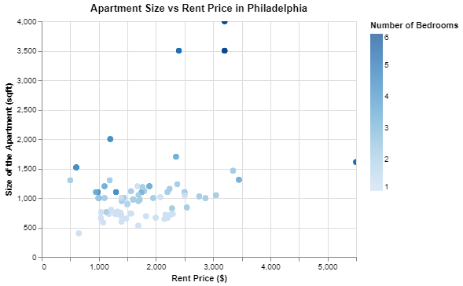

```python
chart = alt.Chart(results).mark_circle(size=50).encode(
    x=alt.X('price:Q', axis=alt.Axis(title='Rent Price ($)')),
    y=alt.Y('size:Q', axis=alt.Axis(title='Size of the Apartment (sqft)')),
    color=alt.Color("brs",legend=alt.Legend(title="Number of Bedrooms")),
    tooltip=[alt.Tooltip("price", title='price ($)'), alt.Tooltip("size", title='size (sqft)'), alt.Tooltip("brs", title='# of bedrooms'), "time", "title"],
).interactive().properties(
title= 'Apartment Size vs Rent Price in Philadelphia'
)

chart
```

From the plot above, the majority of the apartments are in the range of 500-1500 sqft with rent $1000-$3000. We can see a weak trend between size of the apartments and the rent price for apartments within this range. The larger apartments (with more bedrooms) tend to have smaller unit prices.